# Prepare data inputs for the proportional multi-state life table model

Belen Zapata-Diomedi, belen.zapata-diomedi@rmit.edu.au, Alan Both, alan.both@rmit.edu.au

07 August, 2020

## Data inputs

Data inputs for the proportional multi-state life table model (PMSLT) include inputs for: general life table (population, mortality rates and prevalent years lived with disability rates for all causes (YLD)), diseases life tables (incidence and case fatality) and injuries process (mortality rates and years lived with disability rates). Here we prepared inputs for the Melbourne population, when local inputs were available, these were used, otherwise, we used nationally representative inputs. Table 1 describes all data inputs for the MSLT. Each of the MSLT components and related code are explained below Table 1.

Table 1: PMSLT inputs

[output not shown]

### General life table: population numbers and mortality rates

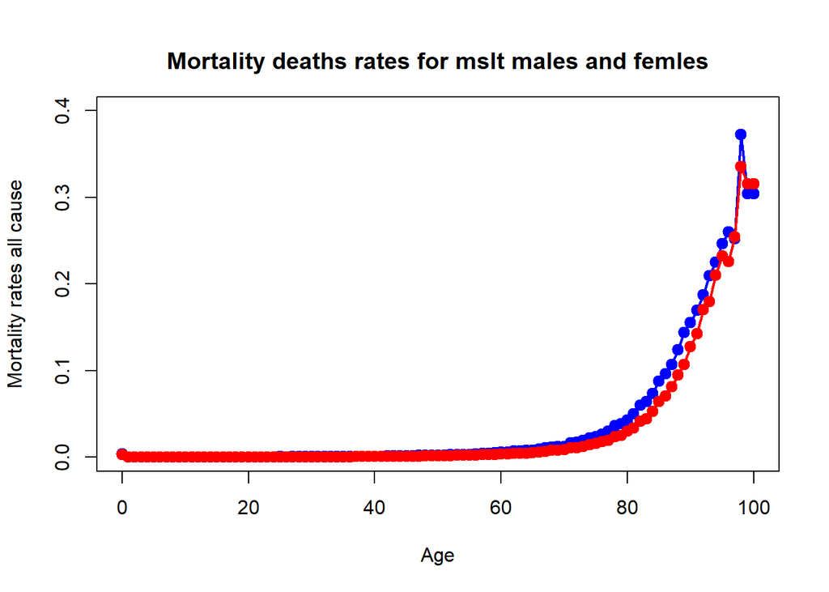

FALSE

### General life table: All cause prevalent Years with Disability (pYLDs)

PYLDs for all causes were obtained in 5 year age groups adn sex from the GBD study for 2017. Interpolation was used to derive rates per single year of age. The function *CalculateMSLT* was used for obtaining pYLDs for all causes.

### Disease life table: disability weights

Disability weights (DW) are derived from disease specific prevalent years lived with disability (YLD) and disease specific prevalence by age group (5 years) and sex. Data for YLDs prevalence from GBD data for 2017. An age and sex specific-correction was introduced to counteract the effects of accumulating comorbid illnesses in the older age groups (Equation 1). Interpolation was used to derive rates per single year of age from 5-year age intervals rates with the funciton *CalculateMSLT*.

$$\begin{equation}
\label{DW adjusted for total YLDs-YLDdPd1YLDt}
(YLDd/Pd)/(1-YLDt) = DW adjusted for total YLDs
\end{equation}$$

Where YLDd is the YLD mean number per age and sex for a given disease, Pd is the prevalence (as reported in GBD ) for a given disease by age and sex and YLDt is total YLD rate per age and sex.

### Disease life table: incidence and case fatality

```r
source("Scripts/data_prep/mslt_gbd_prep.R")
gbd_wider <- calculateGBDwider(
  gbd_location="Data/gbd/gbd_melbourne_mslt.csv"
)
write.csv(gbd_wider, "Data/Processed/gbd_wider.csv", row.names=F, quote=T)
source("Scripts/data_prep/aihw_prep.R")
AIHW <- calculateInputsDismodAIHW (
incidence_AIHW="Data/aihw/cancer_incidence_AIHW_with_projections.xlsx",
mortality_AIHW="Data/aihw/cancer_mortality_AIHW_with_projections.xlsx",
population_deaths_location="Data/Population and deaths/population_deaths.csv"
)
write.csv(AIHW[[1]], "Data/Processed/incidence_AIHW_dismod.csv", row.names=F, quote=T)
write.csv(AIHW[[2]], "Data/Processed/mortality_AIHW_dismod.csv", row.names=F, quote=T)
write.csv(AIHW[[3]], "Data/Processed/population_and_deaths.csv", row.names=F, quote=T)
```

Table 2: Dismod II input data and procedures

[output not shown]

#### Calculate diseases trends

Table 3: Forecast trends for all-cause mortality, diseases and injuries

Input

Inputs

Assumptions

Data processing

General life table: all cause mortality

1. Age-standardised trends by sex applied to all groups, and 2. Number of years trends applied into the future equivalent to the original trends forecast (e.g. if from 2017 to 2020, then trends were applied for 3 years and then stabilised

Disease life table: incidence cancers

Health and Welfare (2020a) forecast from 2017 to 2020

Same above

We derive an annual trend as the log difference between the age standardised rate in 2020 and 2017 divided by the diffence in years

Disease life table: case fatality cancers

Same above

Same above

Disease life table: cardiovascular diseases incidence

Health and Welfare (2020b) hospitallization past trends (actual data) from years 2001 to 2018

Same above and forecast trends were applied to ischemic heart disease and stroke

Future Age standardised rates (ASR) were frist derived from ASR from past trends by sex using linear regression for predominately increasing trends and log-linear regression for decreasing trends. Trends were estimated up to year 2023. Annual trends were derived as above (ln(ASR2023/ASR2018)/years)

Disease life table: cardivarcular disease case fatality

Health and Welfare (2020b) mortality past trends (actual data) from years 2001 to 2018

Same above and forecast trends were applied to ischemic heart disease and stroke

Future Age standardised rates (ASR) were frist derived from ASR from past trends by sex using linear regression for predominately increasing trends and log-linear regression for decreasing trends. Trends were estimated up to year 2023. Annual trends were derived as above (ln(ASR2023/ASR2018)/years)

Disease life table: diabetes incidence

Same as above and trends only applied to incidence

Same as above with forecast up to year 2023

Disease life table: Chronic obstructive pulmonary disease incidence

Health and Welfare (2019) mortality past trends from year 2005 to 2018

Same as above

Same as above

```r
### Alan, there is an issue with the code in the function, trace back and you can see the line.
source("Scripts/data_prep/trends_prep.R")
  trends_diseases <- calculateDiseaseTrends(
  incidence_trends_cancers="Data/aihw/cancer_incidence_AIHW_with_projections.xlsx",
  mortality_trends_cancers="Data/aihw/trends/cancers_trends_mortality_aihw.xls",
  trends_cvd="Data/aihw/trends/cardiovascular_disease_trends_aihw.xlsx",
  grim_books="Data/aihw/trends/grim_books.csv",
  trends_diabetes="Data/aihw/trends/diabetes_trends_aihw.xls"
)

write.csv(trends_diseases[[1]], "Data/Processed/mslt/mortality_trends_f.csv", row.names=F, quote=T)
write.csv(trends_diseases[[2]], "Data/Processed/mslt/mortality_trends_m.csv", row.names=F, quote=T)
write.csv(trends_diseases[[3]], "Data/Processed/mslt/incidence_trends_f.csv", row.names=F, quote=T)
write.csv(trends_diseases[[4]], "Data/Processed/mslt/incidence_trends_m.csv", row.names=F, quote=T)
```

### Generate multi-state life table dataframe

```r
source("Scripts/data_prep/mslt_gbd_prep.R")
mslt <- calculateMSLT(
  population_melbourne_location = "Data/Processed/population_melbourne_abs.csv",
  deaths_melbourne_location= "Data/Processed/deaths_melbourne.csv",
  gbd_wider_location= "Data/Processed/gbd_wider.csv",
  dismod_output_cancers="Data/Processed/dismod_output_cancers.csv",
  dismod_output_non_cancers="Data/Processed/dismod_output_non_cancers.csv")
write.csv(mslt, "Data/Processed/mslt/mslt_df.csv", row.names=F, quote=T)
```

Australian Bureau of Statistics. 2016. “2016 Census : Counting Dwellings, Place of Enumeration.” Dataset.

———. 2019. “Deaths, Australia, 2018.” Dataset. https://www.abs.gov.au/AUSSTATS/abs@.nsf/DetailsPage/3302.02018?OpenDocument.

Carmichael, Gordon A. 2016. “Analysis of Mortality: The Life Table and Survival.” In *Fundamentals of Demographic Analysis: Concepts, Measures and Methods*, 129–211. Cham: Springer International Publishing. https://doi.org/10.1007/978-3-319-23255-3_4.

Global Burden of Disease Collaborative Network. 2018. “Global Burden of Disease Study 2017 (Gbd 2017) Results.” Online Database. http://ghdx.healthdata.org/gbd-results-tool.

Health, Australian Institute of, and Welfare. 2015. “Cancer Mortality Trends and Projections: 2014 to 2025.” Dataset. https://www.aihw.gov.au/reports/cancer/cancer-mortality-trends-and-projections-2014-to-2025.

———. 2019. “General Record of Incidence of Mortality (Grim) Data.” Report. AIHW. https://www.aihw.gov.au/reports/life-expectancy-deaths/grim-books.

———. 2020a. “2020 Cancer Data in Australia.” Online Database. https://www.aihw.gov.au/reports/cancer/cancer-data-in-australia/.

———. 2020b. “Cardiovascular Disease.” Report. AIHW. https://www.aihw.gov.au/reports/heart-stroke-vascular-diseases/cardiovascular-health-compendium.

———. 2020c. “Diabetes.” Report. AIHW. https://www.aihw.gov.au/reports/diabetes/diabetes.

James, Spencer L., Degu Abate, Kalkidan Hassen Abate, Solomon M. Abay, Cristiana Abbafati, Nooshin Abbasi, Hedayat Abbastabar, et al. 2018. “Global, Regional, and National Incidence, Prevalence, and Years Lived with Disability for 354 Diseases and Injuries for 195 Countries and Territories, 1990&#x2013;2017: A Systematic Analysis for the Global Burden of Disease Study 2017.” Journal Article. *The Lancet* 392 (10159): 1789–1858. https://doi.org/10.1016/S0140-6736(18)32279-7.